# STAT 440: Homework Assignment #6

Due: Thursday, Apr. 3 at 11:59pm on Canvas

Some parts of this exercise call for writing code. Please use R, and turn in your code along with your written work and any plots you are asked to produce. Just as you strive for clarity in your writing of language, try to write R code that is easy to read, in the sense that a knowledgeable user of R would be able to understand it easily.

You *may* choose to use LaTeX for your mathematics writing in your homework, in which case I recommend R Markdown as an easy way to combine text, mathematics, R code, and R output. But this is not required; you may choose to format your work however you find convenient, as long as you upload your assignment to Canvas as a single pdf document.

## Exercise 1: Implement a Gibbs Sampler

This exercise revisits Exercise 2 from Homework #5: We assume that the data only consist of a single $X\sim N(\mu, \sigma^2)$, and we also assume *a priori* that $\mu$ and $\sigma^2$ are independent with $\mu\sim N(0,1)$ and $\sigma^2\sim IG(1, 1)$. In other words, the joint prior is the product of the two marginal densities, normal for $\mu$ and inverse gamma for $\sigma^2$, so the prior is
$$\pi(\mu,\sigma^2) \propto \exp\left\{ -\frac{\mu^2}{2} \right\} \times
(\sigma^2)^{-2} \exp\left\{ -\frac{1}{\sigma^2} \right\}$$
and the likelihood is
$$L(\mu, \sigma^2) \propto (\sigma^2)^{-1/2}
\exp\left\{ -\frac{1}{2\sigma^2} (X - \mu)^2 \right\}.$$

**Part (a)** Based on these facts, write down a function that is proportional to the posterior.

**Part (b)** Using part (a), derive the full conditional density for $\mu$ given $\sigma^2$ and $X$.

This simply means that you should treat $\sigma^2$ and $X$ as constants, view the answer from part (a) as a function of $\mu$, and identify what type of density function this function of $\mu$ matches.

**Hint:** The answer should be of the form
$$\mu | \sigma^2 , X \sim N(a, b)$$
where $a$ and $b$ are functions of $\sigma^2$ and $X$.

**Part (c)** Using part (a), derive the full conditional density for $\sigma^2$ given $\mu$ and $X$.

This simply means that you should treat $\mu$ and $X$ as constants, view the answer from part (a) as a function of $\sigma^2$, and identify what type of density function this function of $\sigma^2$ matches.

**Hint:** The answer should be of the form
$$\sigma^2 | \mu , X \sim {\rm InvGamma}(c, d)$$
where $c$ and $d$ are functions of $\sigma^2$ and $X$. The inverse gamma $(c,d)$ density function has the form
$$f(\sigma^2) \propto \left(\frac{1}{\sigma^2}\right)^{c+1}
\exp\left\{ -\frac{d}{\sigma^2} \right\}
\quad \mbox{for $\sigma^2>0$.}$$

**Part (d)** Initialize $\mu_c = 0$ and $\sigma^2_c=1$. Assume we observe $X=1.2$ as in Exercise 2 of Homework #5. Implement 10,000 steps of Gibbs sampling in which each step samples a new $\mu$ from the full conditional in Part (b) (using the most recent $\sigma^2$ value), then samples a new $\sigma^2$ from the full conditional in Part (c) (using the newly sampled $\mu$ value).

To sample from ${\rm InvGamma}(c,d)$, you can use `1/rgamma(1, shape=c, rate=d)`. In other words, the reciprocal of a gamma random variable with shape $c$ and rate $d$ is distributed as ${\rm InvGamma}(c,d)$.

When you finish, you should have 10,000 bivariate $(\mu,\sigma^2)$ vectors that represent an approximate MCMC-based sample from the true posterior.

**Part (e)** Create a 2-dimensional scatterplot of your 10,000 recorded values of $(\mu, \sigma^2)$. Compare this scatterplot to the scatterplot that you produced in Exercise 2(d) of Homework #5 and verify that the two scatterplots look similar.

**Part (f)** Calculate marginal posterior sample means and standard deviations for both $\mu$ and $\sigma^2$ using both your Gibbs sampler (Homework #6) and your M-H sampler with normal proposal (Homework #5). Compare the two methods; they should be quite similar since they are both designed to sample from the same target posterior distribution.

### Answer

[figure not shown]

Hand written solution to part a

[figure not shown]

Hand written solution to part b

[figure not shown]

Hand written solution to part c

**Part (d)**

```r
fMu <- function(sigsq){
  rnorm(n = 1, mean = 1.2/(1 + sigsq), sd = sqrt(sigsq/(1+sigsq)))
}

fSigsq <- function(mu){
  1/rgamma(n = 1, shape = 3/2, rate = ((1/2) * (1.2-mu)^2) + 1)
}

muC <- 0 ; sigsqC <- 1
samples <- data.frame(mu = numeric(10000), sigsq = numeric(10000))

set.seed(440)



for (i in 1:10000) {
  # Step 2: Generate proposed values
  muC <- fMu(sigsqC)
  sigsqC <- fSigsq(muC)

  # we dont need an acceptance probability since it will always be 1
  # this also means that we dont have a proposal, since it will always be accepted

  samples[i, ] <- c(muC, sigsqC)#store values of mu and sigsq current
}
```

**Part (e)**

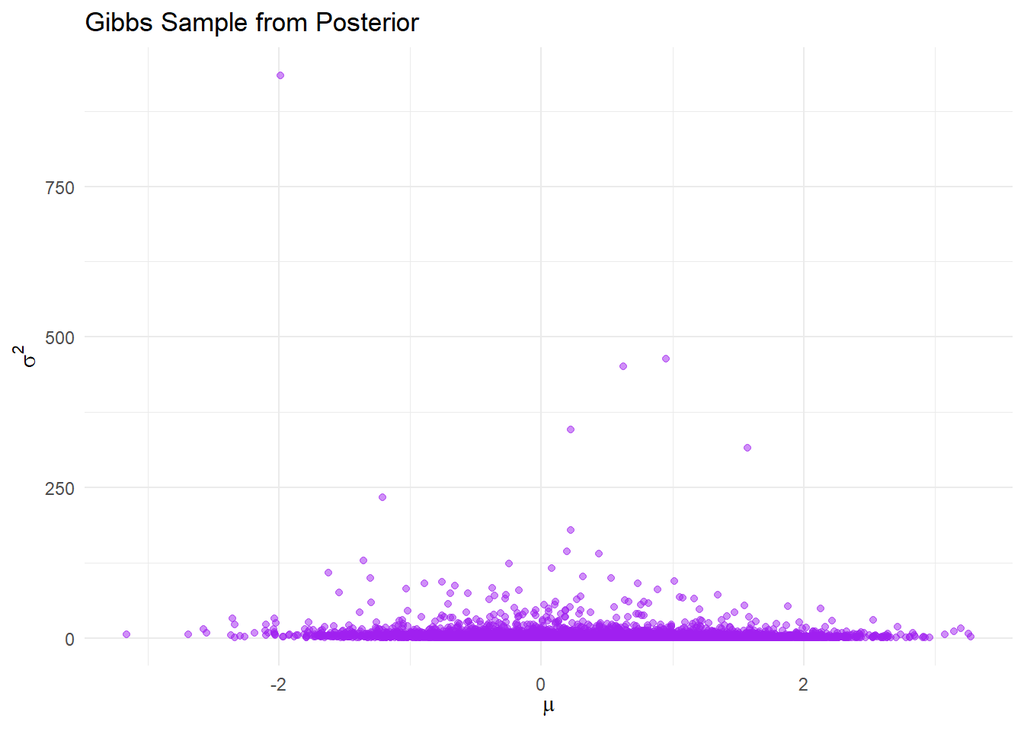

```r
ggplot(samples, aes(x = mu, y = sigsq)) +
  geom_point(alpha = 0.5, color = "purple") +
  labs(x = expression(mu), y = expression(sigma^2),
       title = "Gibbs Sample from Posterior") +
  theme_minimal()
```

### Now look at the graph from the Metropolis Hastings sampler

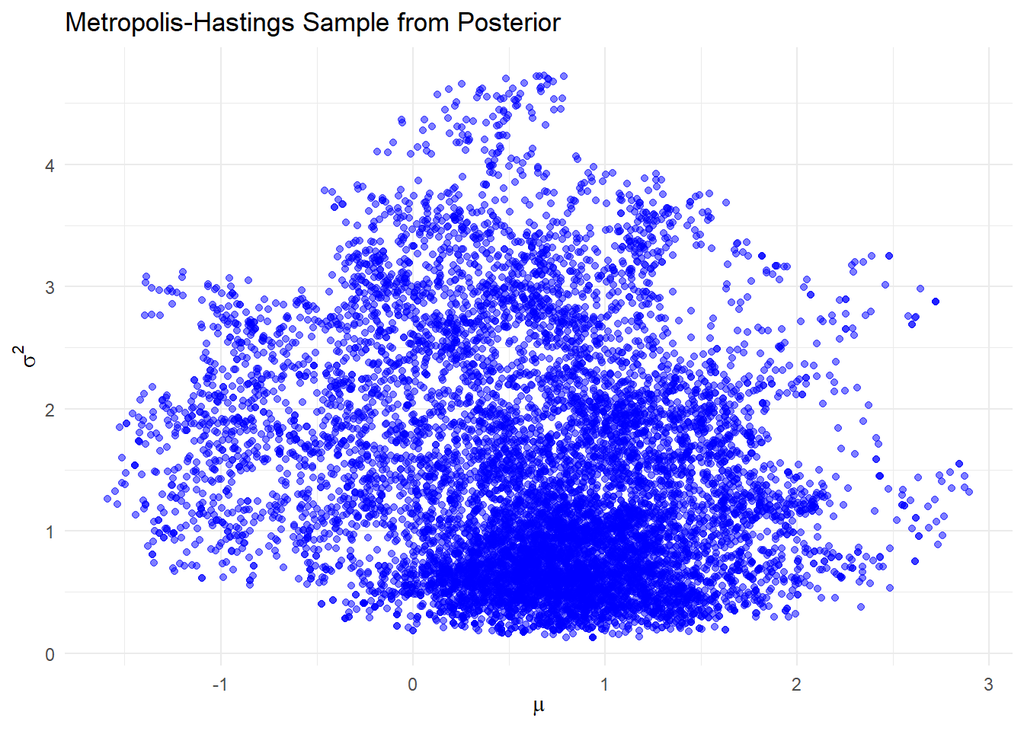

We can’t really see much of the Gibb’s sampler because the graph is skewed by the outliers, so we can just look at the part that whithin reasonable range for the variance.

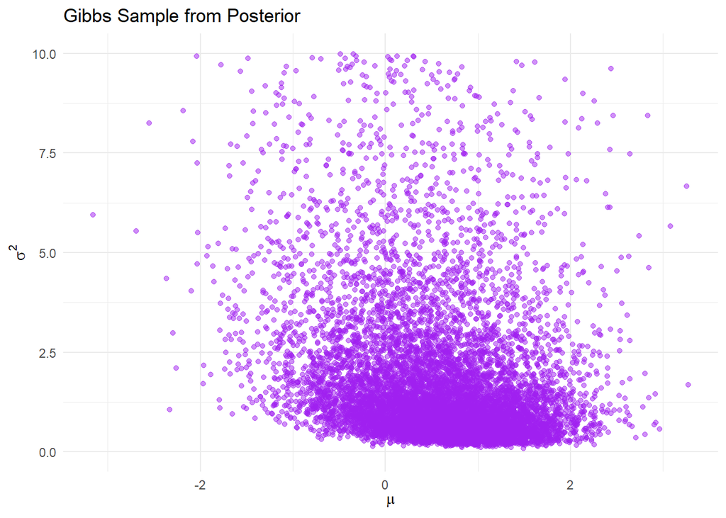

```r
ggplot(samples, aes(x = mu, y = sigsq)) +
  geom_point(alpha = 0.5, color = "purple") +
  labs(x = expression(mu), y = expression(sigma^2),
       title = "Gibbs Sample from Posterior") +
  theme_minimal() +
  ylim(0,10)
```

**Part (f)**

```r
gibbs_mean_mu <- mean(samples$mu)
gibbs_var_mu <- var(samples$mu)
gibbs_mean_sigsq <- mean(samples$sigsq)
gibbs_var_sigsq <- var(samples$sigsq)

# Compute summary statistics for Metropolis-Hastings
mh_mean_mu <- mean(samplesMH$mu)
mh_var_mu <- var(samplesMH$mu)
mh_mean_sigsq <- mean(samplesMH$sigsq)
mh_var_sigsq <- var(samplesMH$sigsq)

# Create a summary table
comparison_table <- data.frame(
  Method = c("Gibbs", "Metropolis-Hastings"),
  Mean_Mu = c(gibbs_mean_mu, mh_mean_mu),
  Variance_Mu = c(gibbs_var_mu, mh_var_mu),
  Mean_Sigsq = c(gibbs_mean_sigsq, mh_mean_sigsq),
  Variance_Sigsq = c(gibbs_var_sigsq, mh_var_sigsq)
)

# Print table
print(comparison_table)
```

```
##                Method   Mean_Mu Variance_Mu Mean_Sigsq Variance_Sigsq
## 1               Gibbs 0.5475704   0.6137809   3.053637     203.658933
## 2 Metropolis-Hastings 0.6557632   0.5224402   1.455984       0.886059
```